# Lesson 2, Part 2

## Git Log

Now that we’ve made a few commits, we can start to look at how our project is evolving. Git log is a good way to do this; we’ve seen this before, but now we’ll see a bit more

```bash
git log
```

This is a very flexible command, however, and there are a few ways we can clean it up to make the output a bit tidier:

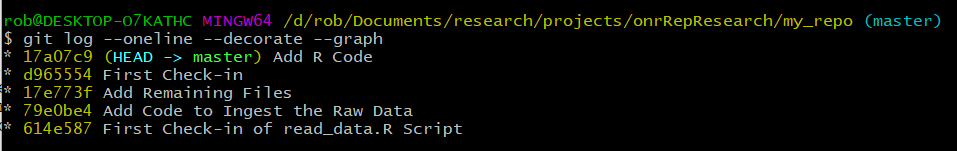

```bash
git log --oneline --decorate --graph
```

## File Management with Git - rm and mv

One thing that is good to remember is that you’ve added a file to git, then it’s being tracked until you delete it. And actually even if you delete it, it gets stored in previous commits - because it *was* in that repo at one point in time. Though the file is just a file, once it’s tracked, don’t be tempted to remove it via the operating system.

If you want to delete a file, or if you want to change it’s name, git offers utlities to do this. Not surprisingly, they are `git rm` and `git mv`. Let’s see them in operation. First we’ll add two files - one to move/rename and one to delete. We’ll add these files tothe `src` directory.

```bash
touch src/prediction.R
touch src/simData.R
git add .
git commit -m "Add Two Files for Experimenting with Moving and Deleting"
```

With these setup and added, let’s delete it at the command line just to see what happens:

```bash
rm src/prediction.R
```

All looks good right from the OS point of view - right? What happens when you ask `git` what the status is?

```bash
git status
```

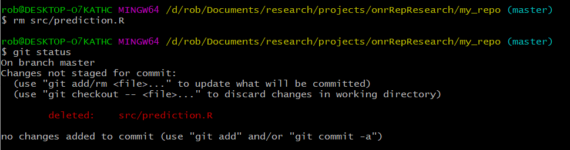

What to do now? Well we have options. One thing we could do is to add the deleted file with `git add`, which is kind of confusing.

Or we could back out the change, and do the deletions using `git`. We do that with the git checkout command. (**n.b.** again - look at the help from git status - it tells you a lot.)

```bash
git checkout -- src/prediction.R
git status
```

Now we’re back to a clean working directory.

Instead of removing the file with `rm`, let’s use `git` to do this. Note that when you use `git` to do this, you’ll see the status looks very different. Using `rm` makes a change (the deletion) that hasn’t been staged, where as the second (`git rm`) makes a change that is staged and ready to be committed:

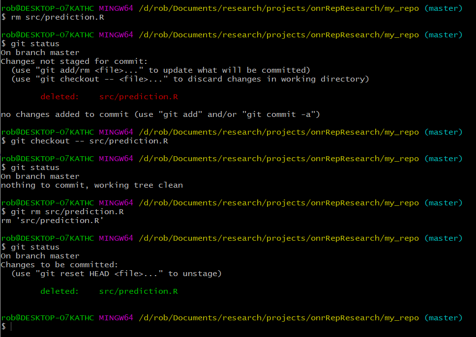

Basically to get a clean working directory if you go the `rm` route, you have to **add** the file to the staging area, only to then commit it. `git rm` just does that for you in one step.

Now that that is clear, it is a good time to commit the deletion.

```bash
git commit -m "Delete prediction.R File"
```

With that file gone and the repo in a clean state, let’s rename the other file - this time using `git`. As above, if you use git’s utilities for this, you don’t have to add the changes. So instead of `mv` we’ll use `git mv`:

```bash
git mv src/simData.R src/simXYData.R
git commit -m "Rename Simulation Script for Clarity"
```

## Time for a Break

Before we move on to replicating this in RStudio, it’s probably time for a break.

[figure not shown]